# Laboratorio 8

2026-04-26

## Link de Repositorio

https://github.com/Cisco890/Laboratorio_8.git

## Preparacion del entorno analitico

```r
paquetes_requeridos <- c("tidyverse", "caret", "e1071", "kernlab", "knitr")
paquetes_opcionales <- c("MLmetrics")

for (pkg in paquetes_requeridos) {
  if (!requireNamespace(pkg, quietly = TRUE)) {
    stop(paste("Falta instalar el paquete requerido:", pkg))
  }
  suppressPackageStartupMessages(library(pkg, character.only = TRUE))
}

for (pkg in paquetes_opcionales) {
  if (requireNamespace(pkg, quietly = TRUE)) {
    suppressPackageStartupMessages(library(pkg, character.only = TRUE))
  } else {
    message("Paquete opcional no disponible en este entorno: ", pkg)
  }
}

set.seed(123)
```

Este documento prepara los datos para clasificacion con SVM sobre la variable objetivo categorica de precio. Se prioriza reproducibilidad, limpieza del flujo y trazabilidad del particionamiento experimental.

## Carga y diagnostico inicial del conjunto de datos

```r
objetos_cargados <- load("listings.RData")

if ("listings" %in% objetos_cargados) {
  datos <- get("listings")
} else {
  candidatos_df <- objetos_cargados[sapply(objetos_cargados, function(x) is.data.frame(get(x)))]
  if (length(candidatos_df) == 0) {
    stop("No se encontro ningun data frame en listings.RData")
  }
  datos <- get(candidatos_df[1])
}

datos <- as.data.frame(datos)
```

```r
cat("Objeto usado:", if ("listings" %in% objetos_cargados) "listings" else "primer data.frame encontrado", "\n")
```

```
## Objeto usado: listings
```

```r
cat("Dimensiones:", nrow(datos), "filas x", ncol(datos), "columnas\n")
```

```
## Dimensiones: 171748 filas x 80 columnas
```

```r
resumen_tipos <- tibble(
  variable = names(datos),
  clase = sapply(datos, function(x) paste(class(x), collapse = ", ")),
  n_unicos = sapply(datos, function(x) dplyr::n_distinct(x, na.rm = TRUE)),
  na_count = sapply(datos, function(x) sum(is.na(x))),
  na_pct = round(100 * na_count / nrow(datos), 2)
)

resumen_tipos %>%
  count(clase, sort = TRUE) %>%
  kable(caption = "Cantidad de variables por tipo")
```

Cantidad de variables por tipo

| clase | n |
| --- | --- |
| character | 37 |
| integer | 27 |
| numeric | 15 |
| logical | 1 |

```r
resumen_tipos %>%
  arrange(desc(na_count)) %>%
  slice_head(n = 20) %>%
  kable(caption = "Top 20 variables con mas valores faltantes")
```

Top 20 variables con mas valores faltantes

| variable | clase | n_unicos | na_count | na_pct |
| --- | --- | --- | --- | --- |
| calendar_updated | logical | 0 | 171748 | 100.00 |
| estimated_revenue_l365d | integer | 9746 | 95502 | 55.61 |
| price | character | 2321 | 89381 | 52.04 |
| neighbourhood_group_cleansed | character | 17 | 50683 | 29.51 |
| review_scores_location | numeric | 184 | 40328 | 23.48 |
| review_scores_value | numeric | 187 | 40328 | 23.48 |
| review_scores_checkin | numeric | 152 | 40324 | 23.48 |
| review_scores_accuracy | numeric | 171 | 40312 | 23.47 |
| review_scores_communication | numeric | 161 | 40308 | 23.47 |
| review_scores_cleanliness | numeric | 195 | 40302 | 23.47 |
| review_scores_rating | numeric | 176 | 40287 | 23.46 |
| reviews_per_month | numeric | 1236 | 40287 | 23.46 |
| beds | integer | 40 | 31686 | 18.45 |
| bathrooms | numeric | 38 | 31396 | 18.28 |
| license | character | 52058 | 10533 | 6.13 |
| bedrooms | integer | 23 | 10473 | 6.10 |
| host_listings_count | integer | 394 | 876 | 0.51 |
| host_total_listings_count | integer | 481 | 876 | 0.51 |
| minimum_minimum_nights | integer | 185 | 71 | 0.04 |
| maximum_minimum_nights | integer | 211 | 71 | 0.04 |

```r
if ("price" %in% names(datos) && is.character(datos$price)) {
  datos <- datos %>% mutate(price = readr::parse_number(price))
}

if (!"price" %in% names(datos)) {
  stop("No existe la variable 'price' en el conjunto de datos.")
}
```

En esta base, la variable `price` se encuentra como texto con simbolos monetarios y se convierte a formato numerico para poder construir la variable objetivo y evitar problemas en modelado.

## Reutilizacion del particionamiento experimental

```r
detectar_particion_previa <- function(datos_base) {
  resultado <- list(
    encontrada = FALSE,
    fuente = NA_character_,
    train = NULL,
    test = NULL,
    train_index = NULL
  )

  # Caso 1: objetos train/test ya presentes en el ambiente.
  if (exists("train", inherits = FALSE) && exists("test", inherits = FALSE)) {
    tr <- get("train")
    te <- get("test")
    if (is.data.frame(tr) && is.data.frame(te)) {
      resultado$encontrada <- TRUE
      resultado$fuente <- "objetos train/test ya presentes en el ambiente"
      resultado$train <- tr
      resultado$test <- te
      return(resultado)
    }
  }

  # Caso 2: archivos comunes de particion.
  candidatos <- list.files(
    path = ".",
    recursive = TRUE,
    full.names = TRUE,
    pattern = "(?i)(train|test|split|particion|partition).*(\\.rds|\\.rda|\\.RData)$"
  )

  if (length(candidatos) == 0) {
    return(resultado)
  }

  for (archivo in candidatos) {
    ext <- tolower(tools::file_ext(archivo))

    if (ext == "rds") {
      obj <- tryCatch(readRDS(archivo), error = function(e) NULL)
      if (is.null(obj)) next

      # Formato lista con train/test.
      if (is.list(obj) && all(c("train", "test") %in% names(obj))) {
        if (is.data.frame(obj$train) && is.data.frame(obj$test)) {
          resultado$encontrada <- TRUE
          resultado$fuente <- paste("archivo", archivo, "(lista train/test)")
          resultado$train <- obj$train
          resultado$test <- obj$test
          return(resultado)
        }
      }

      # Formato lista con indice.
      if (is.list(obj) && "train_index" %in% names(obj)) {
        idx <- obj$train_index
        if (is.numeric(idx) && all(idx >= 1) && all(idx <= nrow(datos_base))) {
          resultado$encontrada <- TRUE
          resultado$fuente <- paste("archivo", archivo, "(indice train)")
          resultado$train_index <- idx
          resultado$train <- datos_base[idx, , drop = FALSE]
          resultado$test <- datos_base[-idx, , drop = FALSE]
          return(resultado)
        }
      }
    }

    if (ext %in% c("rda", "rdata")) {
      env_tmp <- new.env(parent = emptyenv())
      cargados <- tryCatch(load(archivo, envir = env_tmp), error = function(e) character(0))
      if (length(cargados) == 0) next

      if (all(c("train", "test") %in% ls(env_tmp))) {
        tr <- get("train", envir = env_tmp)
        te <- get("test", envir = env_tmp)
        if (is.data.frame(tr) && is.data.frame(te)) {
          resultado$encontrada <- TRUE
          resultado$fuente <- paste("archivo", archivo, "(objetos train/test)")
          resultado$train <- tr
          resultado$test <- te
          return(resultado)
        }
      }
    }
  }

  resultado
}

if (!"price_category" %in% names(datos)) {
  q1 <- quantile(datos$price, 1 / 3, na.rm = TRUE)
  q2 <- quantile(datos$price, 2 / 3, na.rm = TRUE)

  datos <- datos %>%
    mutate(
      price_category = case_when(
        price <= q1 ~ "barata",
        price <= q2 ~ "media",
        TRUE ~ "cara"
      ),
      price_category = factor(price_category, levels = c("barata", "media", "cara"))
    )
} else {
  datos <- datos %>%
    mutate(price_category = as.factor(price_category))
}

particion_previa <- detectar_particion_previa(datos)

if (isTRUE(particion_previa$encontrada)) {
  train <- particion_previa$train
  test <- particion_previa$test
  fuente_particion <- particion_previa$fuente
} else {
  set.seed(123)
  indice_train <- createDataPartition(datos$price_category, p = 0.8, list = FALSE)

  train <- datos[indice_train, , drop = FALSE]
  test <- datos[-indice_train, , drop = FALSE]

  fuente_particion <- "reconstruida con set.seed(123) y createDataPartition()"

  dir.create("artefactos", showWarnings = FALSE)
  saveRDS(list(train_index = indice_train), file = "artefactos/particion_train_idx.rds")
}

cat("Fuente de particionamiento:", fuente_particion, "\n")
```

```
## Fuente de particionamiento: archivo ./artefactos/particion_train_idx.rds (indice train)
```

```r
cat("Dimensiones train:", paste(dim(train), collapse = " x "), "\n")
```

```
## Dimensiones train: 137400 x 81
```

```r
cat("Dimensiones test :", paste(dim(test), collapse = " x "), "\n")
```

```
## Dimensiones test : 34348 x 81
```

```r
prop_train <- prop.table(table(train$price_category))
prop_test <- prop.table(table(test$price_category))

tabla_props <- bind_rows(
  tibble(conjunto = "train", categoria = names(prop_train), proporcion = as.numeric(prop_train)),
  tibble(conjunto = "test", categoria = names(prop_test), proporcion = as.numeric(prop_test))
)

tabla_props %>%
  pivot_wider(names_from = conjunto, values_from = proporcion) %>%
  mutate(diferencia_abs = abs(train - test)) %>%
  kable(digits = 4, caption = "Comparacion de proporciones por categoria de precio")
```

Comparacion de proporciones por categoria de precio

| categoria | train | test | diferencia_abs |
| --- | --- | --- | --- |
| barata | 0.1496 | 0.1496 | 0 |
| media | 0.1465 | 0.1464 | 0 |
| cara | 0.7040 | 0.7040 | 0 |

Las proporciones por categoria entre entrenamiento y prueba se mantienen comparables, lo cual permite contrastar modelos futuros bajo condiciones experimentales consistentes.

## Diagnostico inicial de predictores

```r
glimpse(train)
```

```
## Rows: 137,400
## Columns: 81
## $ id                                           <dbl> 6448, 8502, 22828, 47572,…
## $ listing_url                                  <chr> "https://www.airbnb.com/r…
## $ scrape_id                                    <dbl> 2.025092e+13, 2.025092e+1…
## $ last_scraped                                 <chr> "2025-09-17", "2025-09-17…
## $ source                                       <chr> "city scrape", "city scra…
## $ name                                         <chr> "Secluded Studio @ Zilker…
## $ description                                  <chr> "Clean, private space wit…
## $ neighborhood_overview                        <chr> "The neighborhood is fun …
## $ picture_url                                  <chr> "https://a0.muscache.com/…
## $ host_id                                      <int> 14156, 25298, 56488, 2159…
## $ host_url                                     <chr> "https://www.airbnb.com/u…
## $ host_name                                    <chr> "Amy", "Karen", "David", …
## $ host_since                                   <chr> "2009-04-20", "2009-07-11…
```

[output cut: 68 more lines]

```r
resumen_numericas <- train %>%
  summarise(across(where(is.numeric), list(
    media = ~ mean(.x, na.rm = TRUE),
    sd = ~ sd(.x, na.rm = TRUE),
    min = ~ min(.x, na.rm = TRUE),
    max = ~ max(.x, na.rm = TRUE)
  )))

resumen_na <- train %>%
  summarise(across(everything(), ~ sum(is.na(.x)))) %>%
  pivot_longer(everything(), names_to = "variable", values_to = "na_count") %>%
  mutate(na_pct = 100 * na_count / nrow(train)) %>%
  arrange(desc(na_count))

perfil_categoricas <- train %>%
  select(where(~ is.character(.x) || is.factor(.x))) %>%
  summarise(across(everything(), ~ n_distinct(.x, na.rm = TRUE))) %>%
  pivot_longer(everything(), names_to = "variable", values_to = "n_categorias") %>%
  arrange(desc(n_categorias))

resumen_na %>%
  slice_head(n = 20) %>%
  kable(caption = "Variables con mayor cantidad de NA en entrenamiento")
```

Variables con mayor cantidad de NA en entrenamiento

| variable | na_count | na_pct |
| --- | --- | --- |
| calendar_updated | 137400 | 100.0000000 |
| price | 76466 | 55.6521106 |
| estimated_revenue_l365d | 76466 | 55.6521106 |
| neighbourhood_group_cleansed | 40600 | 29.5487627 |
| review_scores_value | 32269 | 23.4854440 |
| review_scores_location | 32268 | 23.4847162 |
| review_scores_checkin | 32265 | 23.4825328 |
| review_scores_accuracy | 32255 | 23.4752547 |
| review_scores_communication | 32251 | 23.4723435 |
| review_scores_cleanliness | 32247 | 23.4694323 |
| review_scores_rating | 32237 | 23.4621543 |
| reviews_per_month | 32237 | 23.4621543 |
| beds | 25356 | 18.4541485 |
| bathrooms | 25120 | 18.2823872 |
| license | 8455 | 6.1535662 |
| bedrooms | 8342 | 6.0713246 |
| host_listings_count | 701 | 0.5101892 |
| host_total_listings_count | 701 | 0.5101892 |
| minimum_minimum_nights | 54 | 0.0393013 |
| maximum_minimum_nights | 54 | 0.0393013 |

```r
perfil_categoricas %>%
  slice_head(n = 20) %>%
  kable(caption = "Variables categoricas con mayor cardinalidad")
```

Variables categoricas con mayor cardinalidad

| variable | n_categorias |
| --- | --- |
| listing_url | 137400 |
| picture_url | 134531 |
| name | 131353 |
| amenities | 121138 |
| description | 115584 |
| host_url | 66581 |
| host_picture_url | 64441 |
| host_thumbnail_url | 64415 |
| neighborhood_overview | 50122 |
| license | 42592 |
| host_about | 35387 |
| host_name | 19852 |
| host_since | 5929 |
| first_review | 5171 |
| last_review | 3795 |
| host_neighbourhood | 2677 |
| host_location | 2574 |
| neighbourhood_cleansed | 853 |
| property_type | 110 |
| host_acceptance_rate | 103 |

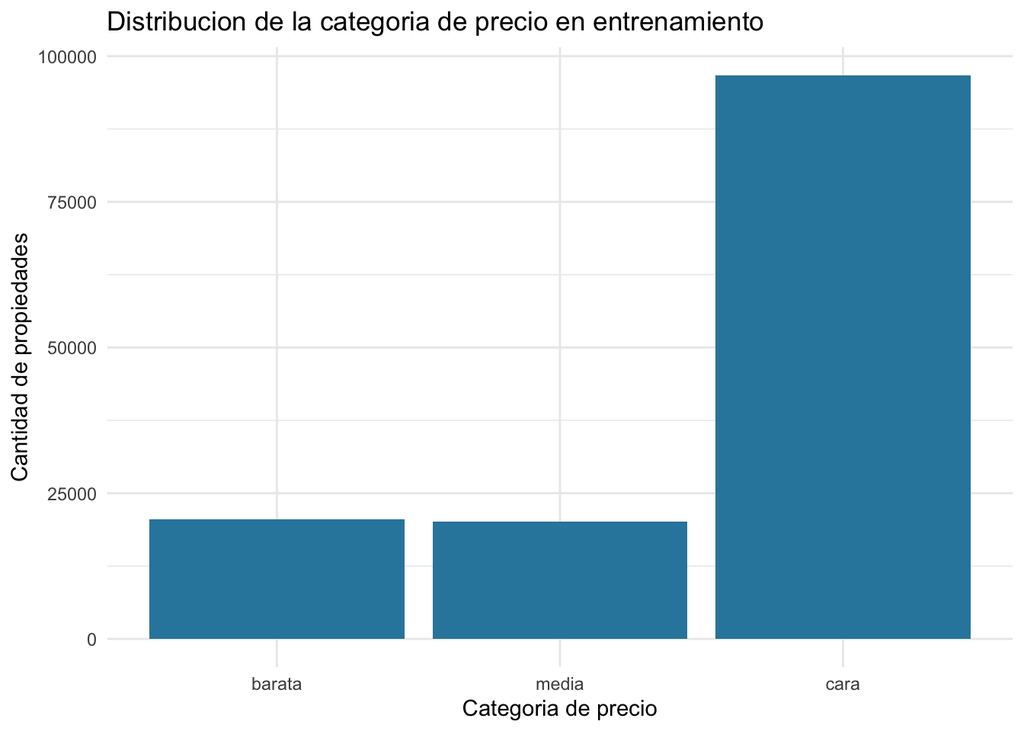

```r
ggplot(train, aes(x = price_category)) +
  geom_bar(fill = "#2E86AB") +
  labs(
    title = "Distribucion de la categoria de precio en entrenamiento",
    x = "Categoria de precio",
    y = "Cantidad de propiedades"
  ) +
  theme_minimal()
```

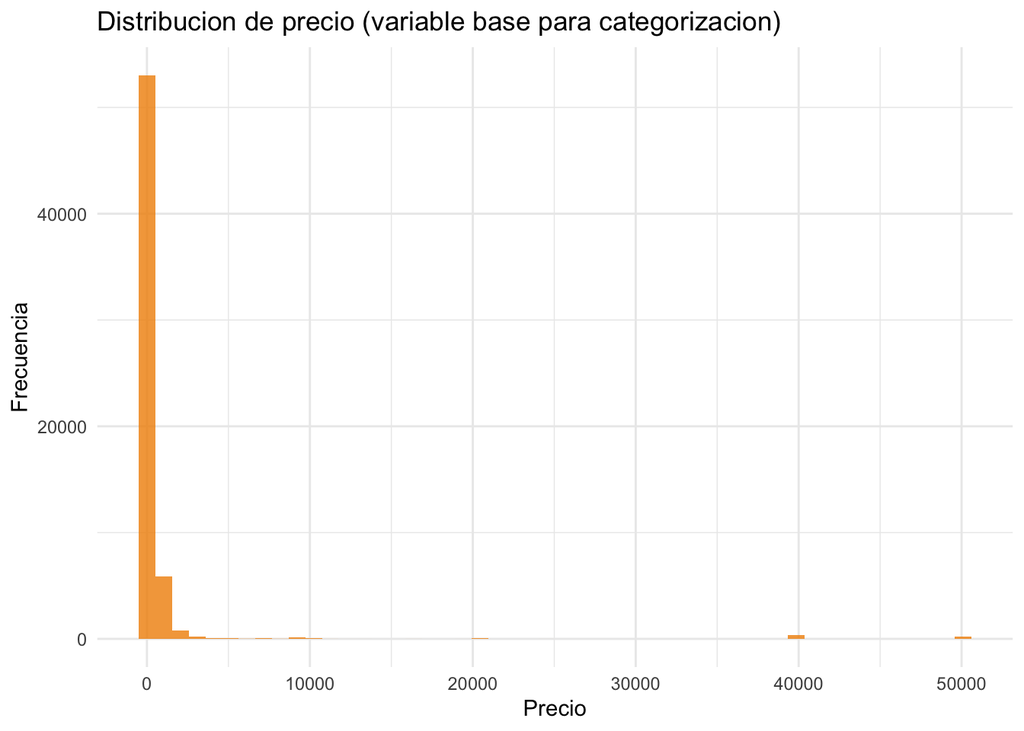

```r
ggplot(train, aes(x = price)) +
  geom_histogram(bins = 50, fill = "#F18F01", alpha = 0.8) +
  labs(
    title = "Distribucion de precio (variable base para categorizacion)",
    x = "Precio",
    y = "Frecuencia"
  ) +
  theme_minimal()
```

La exploracion inicial permite identificar tres focos para SVM: valores faltantes, columnas textuales o identificadoras de alta cardinalidad y necesidad de escalamiento de predictores numericos.

## Transformaciones para modelado SVM

```r
# Limpieza minima de la variable objetivo.
train <- train %>% mutate(price_category = factor(price_category, levels = c("barata", "media", "cara")))
test <- test %>% mutate(price_category = factor(price_category, levels = levels(train$price_category)))

# Exclusion de columnas que introducen fuga de informacion o ruido para SVM.
patrones_id <- "(^id$|_id$|url|name$|description|about|picture|thumbnail|host_url|listing_url|scrape_id|calendar_last_scraped)"
cols_patron <- names(train)[str_detect(names(train), regex(patrones_id, ignore_case = TRUE))]

cols_all_na <- names(train)[sapply(train, function(x) all(is.na(x)))]

# Variables categoricas de cardinalidad extrema.
cat_cols <- names(train)[sapply(train, function(x) is.character(x) || is.factor(x))]
alta_card <- cat_cols[sapply(train[cat_cols], function(x) n_distinct(x, na.rm = TRUE) > 100)]

columnas_excluir <- unique(c("price", cols_patron, cols_all_na, alta_card))
columnas_excluir <- setdiff(columnas_excluir, "price_category")

train_model <- train %>% select(-any_of(columnas_excluir))
test_model <- test %>% select(-any_of(columnas_excluir))

# Separacion de X e y.
y_train <- train_model$price_category
y_test <- test_model$price_category

x_train_base <- train_model %>% select(-price_category)
x_test_base <- test_model %>% select(-price_category)

# Conversion de categoricas a dummies.
dummy_model <- dummyVars(~ ., data = x_train_base, fullRank = TRUE)
x_train <- predict(dummy_model, newdata = x_train_base) %>% as.data.frame()
x_test <- predict(dummy_model, newdata = x_test_base) %>% as.data.frame()

# Alineacion estricta de columnas entre train y test.
cols_faltantes_test <- setdiff(names(x_train), names(x_test))
if (length(cols_faltantes_test) > 0) {
  for (col in cols_faltantes_test) x_test[[col]] <- 0
}

cols_extra_test <- setdiff(names(x_test), names(x_train))
if (length(cols_extra_test) > 0) {
  x_test <- x_test %>% select(-any_of(cols_extra_test))
}

x_test <- x_test[, names(x_train), drop = FALSE]

# Imputacion y escalamiento para SVM.
preprocess_model <- preProcess(x_train, method = c("medianImpute", "center", "scale"))
x_train_scaled <- predict(preprocess_model, x_train)
x_test_scaled <- predict(preprocess_model, x_test)

# Reconstruccion final para entrenamiento y evaluacion.
train_svm <- x_train_scaled %>% mutate(price_category = y_train)
test_svm <- x_test_scaled %>% mutate(price_category = y_test)

train_svm$price_category <- factor(train_svm$price_category, levels = c("barata", "media", "cara"))
test_svm$price_category <- factor(test_svm$price_category, levels = levels(train_svm$price_category))
```

```r
cat("Dimensiones train_svm:", paste(dim(train_svm), collapse = " x "), "\n")
```

```
## Dimensiones train_svm: 137400 x 247
```

```r
cat("Dimensiones test_svm :", paste(dim(test_svm), collapse = " x "), "\n")
```

```
## Dimensiones test_svm : 34348 x 247
```

```r
table(train_svm$price_category)
```

```
##
## barata  media   cara
##  20552  20123  96725
```

```r
table(test_svm$price_category)
```

```
##
## barata  media   cara
##   5137   5030  24181
```

```r
cat("¿Hay NA en train_svm?:", anyNA(train_svm), "\n")
```

```
## ¿Hay NA en train_svm?: FALSE
```

```r
cat("¿Hay NA en test_svm?:", anyNA(test_svm), "\n")
```

```
## ¿Hay NA en test_svm?: FALSE
```

```r
dir.create("artefactos", showWarnings = FALSE)

saveRDS(train_svm, "artefactos/train_svm.rds")
saveRDS(test_svm, "artefactos/test_svm.rds")
saveRDS(dummy_model, "artefactos/dummy_model_svm.rds")
saveRDS(preprocess_model, "artefactos/preprocess_model_svm.rds")
```

## Cierre del avance

Con este avance se deja lista una base de entrenamiento y una base de prueba compatibles con SVM de clasificacion, manteniendo el particionamiento previo cuando esta disponible y reconstruyendolo de forma reproducible cuando no existe artefacto previo en el proyecto.

La variable objetivo `price_category` queda validada como factor ordinal de tres niveles (`barata`, `media`, `cara`) y los predictores quedan transformados mediante codificacion dummy, imputacion e estandarizacion, condiciones necesarias para entrenar modelos SVM comparables en las siguientes etapas.

## Diseno experimental de los modelos SVM

```r
train_svm <- readRDS("artefactos/train_svm.rds")
test_svm  <- readRDS("artefactos/test_svm.rds")

str(train_svm[, c(ncol(train_svm) - 2, ncol(train_svm) - 1, ncol(train_svm))])
```

```
## 'data.frame':    137400 obs. of  3 variables:
##  $ citySan Francisco, California: num  -0.214 -0.214 -0.214 -0.214 -0.214 ...
##  $ cityWashington, D.C.         : num  -0.196 -0.196 -0.196 -0.196 -0.196 ...
##  $ price_category               : Factor w/ 3 levels "barata","media",..: 2 1 1 1 3 2 2 1 1 1 ...
```

```r
str(test_svm[, c(ncol(test_svm) - 2, ncol(test_svm) - 1, ncol(test_svm))])
```

```
## 'data.frame':    34348 obs. of  3 variables:
##  $ citySan Francisco, California: num  -0.214 -0.214 -0.214 -0.214 -0.214 ...
##  $ cityWashington, D.C.         : num  -0.196 -0.196 -0.196 -0.196 -0.196 ...
##  $ price_category               : Factor w/ 3 levels "barata","media",..: 1 2 2 1 1 1 2 3 3 3 ...
```

```r
cat("DistribuciOn en entrenamiento:\n")
```

```
## DistribuciOn en entrenamiento:
```

```r
print(table(train_svm$price_category))
```

```
##
## barata  media   cara
##  20552  20123  96725
```

```r
cat("DistribuciOn en prueba:\n")
```

```
## DistribuciOn en prueba:
```

```r
print(table(test_svm$price_category))
```

```
##
## barata  media   cara
##   5137   5030  24181
```

```r
cat("NA en train_svm:", sum(is.na(train_svm)), "\n")
```

```
## NA en train_svm: 0
```

```r
cat("NA en test_svm: ", sum(is.na(test_svm)),  "\n")
```

```
## NA en test_svm:  0
```

```r
train_svm$price_category <- as.factor(train_svm$price_category)
test_svm$price_category  <- as.factor(test_svm$price_category)
```

```r
x_train <- train_svm %>% select(-price_category)
y_train <- train_svm$price_category

x_test <- test_svm %>% select(-price_category)
y_test <- test_svm$price_category

dif_1 <- setdiff(names(x_train), names(x_test))
dif_2 <- setdiff(names(x_test),  names(x_train))

if (length(dif_1) > 0 || length(dif_2) > 0) {
  warning("Las columnas de train y test no coinciden. Revisar preprocesamiento.")
} else {
  cat("Las columnas de entrenamiento y prueba son identicas.\n")
}
```

```
## Las columnas de entrenamiento y prueba son identicas.
```

Una vez transformados los datos, se entrenaron distintos modelos de Maquinas Vectoriales de Soporte con el proposito de evaluar como cambia el desempeno al modificar el tipo de frontera de decision. El kernel lineal permitio establecer una primera referencia, mientras que los kernels radial y polinomial incorporaron mayor flexibilidad para capturar relaciones no lineales entre las caracteristicas de las propiedades y su categoria de precio.

```r
set.seed(123)
dir.create("artefactos", showWarnings = FALSE, recursive = TRUE)

# Cambia a FALSE si quieres volver al ajuste completo.
modo_rapido_knit <- TRUE
folds_svm <- if (isTRUE(modo_rapido_knit)) 3 else 5
guardar_predicciones_cv <- if (isTRUE(modo_rapido_knit)) "none" else "final"

control_svm <- trainControl(
  method          = "cv",
  number          = folds_svm,
  classProbs      = FALSE,
  savePredictions = guardar_predicciones_cv
)
```

## Evaluacion de kernels para clasificacion de precios

### Kernel lineal

```r
grid_lineal <- if (isTRUE(modo_rapido_knit)) {
  expand.grid(C = 1)
} else {
  expand.grid(C = c(0.1, 1, 10))
}

control_svm_lineal <- if (isTRUE(modo_rapido_knit)) {
  trainControl(
    method = "none",
    classProbs = FALSE,
    savePredictions = "none"
  )
} else {
  control_svm
}

ruta_modelo_lineal <- if (isTRUE(modo_rapido_knit)) {
  "artefactos/modelo_svm_lineal_rapido.rds"
} else {
  "artefactos/modelo_svm_lineal.rds"
}

if (file.exists(ruta_modelo_lineal)) {
  modelo_svm_lineal <- readRDS(ruta_modelo_lineal)
  tiempo_lineal <- c(elapsed = NA_real_)
} else {
  x_train_lineal <- x_train
  y_train_lineal <- y_train

  if (isTRUE(modo_rapido_knit)) {
    n_max_lineal <- min(3000, nrow(x_train))
    idx_lineal <- sample(seq_len(nrow(x_train)), size = n_max_lineal)
    x_train_lineal <- x_train[idx_lineal, , drop = FALSE]
    y_train_lineal <- y_train[idx_lineal]
  }

  set.seed(123)
  tiempo_lineal <- system.time({
    modelo_svm_lineal <- train(
      x         = x_train_lineal,
      y         = y_train_lineal,
      method    = "svmLinear",
      trControl = control_svm_lineal,
      tuneGrid  = grid_lineal,
      metric    = "Accuracy"
    )
  })
  saveRDS(modelo_svm_lineal, ruta_modelo_lineal)
}

modelo_svm_lineal
```

```
## Support Vector Machines with Linear Kernel
##
## 3000 samples
##  246 predictor
##    3 classes: 'barata', 'media', 'cara'
##
## No pre-processing
## Resampling: None
```

```r
if (!isTRUE(modo_rapido_knit)) {
  plot(modelo_svm_lineal, main = "Accuracy vs. C - kernel lineal")
}
```

### Kernel radial

```r
grid_radial <- if (isTRUE(modo_rapido_knit)) {
  expand.grid(C = 1, sigma = 0.05)
} else {
  expand.grid(
    C     = c(0.1, 1, 10),
    sigma = c(0.01, 0.05, 0.1)
  )
}

control_svm_radial <- if (isTRUE(modo_rapido_knit)) {
  trainControl(
    method = "none",
    classProbs = FALSE,
    savePredictions = "none"
  )
} else {
  control_svm
}

ruta_modelo_radial <- if (isTRUE(modo_rapido_knit)) {
  "artefactos/modelo_svm_radial_rapido.rds"
} else {
  "artefactos/modelo_svm_radial.rds"
}

if (file.exists(ruta_modelo_radial)) {
  modelo_svm_radial <- readRDS(ruta_modelo_radial)
  tiempo_radial <- c(elapsed = NA_real_)
} else {
  x_train_radial <- x_train
  y_train_radial <- y_train

  if (isTRUE(modo_rapido_knit)) {
    n_max_radial <- min(3000, nrow(x_train))
    idx_radial <- sample(seq_len(nrow(x_train)), size = n_max_radial)
    x_train_radial <- x_train[idx_radial, , drop = FALSE]
    y_train_radial <- y_train[idx_radial]
  }

  set.seed(123)
  tiempo_radial <- system.time({
    modelo_svm_radial <- train(
      x         = x_train_radial,
      y         = y_train_radial,
      method    = "svmRadial",
      trControl = control_svm_radial,
      tuneGrid  = grid_radial,
      metric    = "Accuracy"
    )
  })
  saveRDS(modelo_svm_radial, ruta_modelo_radial)
}

modelo_svm_radial
```

```
## Support Vector Machines with Radial Basis Function Kernel
##
## 3000 samples
##  246 predictor
##    3 classes: 'barata', 'media', 'cara'
##
## No pre-processing
## Resampling: None
```

```r
if (!isTRUE(modo_rapido_knit)) {
  plot(modelo_svm_radial, main = "Accuracy vs. C y sigma - kernel radial")
}
```

### Kernel polinomial

```r
grid_polinomial <- if (isTRUE(modo_rapido_knit)) {
  expand.grid(degree = 2, scale = 0.05, C = 1)
} else {
  expand.grid(
    degree = c(2, 3),
    scale  = c(0.01, 0.05, 0.1),
    C      = c(0.1, 1, 10)
  )
}

control_svm_polinomial <- if (isTRUE(modo_rapido_knit)) {
  trainControl(
    method = "none",
    classProbs = FALSE,
    savePredictions = "none"
  )
} else {
  control_svm
}

ruta_modelo_polinomial <- if (isTRUE(modo_rapido_knit)) {
  "artefactos/modelo_svm_polinomial_rapido.rds"
} else {
  "artefactos/modelo_svm_polinomial.rds"
}

if (file.exists(ruta_modelo_polinomial)) {
  modelo_svm_polinomial <- readRDS(ruta_modelo_polinomial)
  tiempo_polinomial <- c(elapsed = NA_real_)
} else {
  x_train_polinomial <- x_train
  y_train_polinomial <- y_train

  if (isTRUE(modo_rapido_knit)) {
    n_max_polinomial <- min(3000, nrow(x_train))
    idx_polinomial <- sample(seq_len(nrow(x_train)), size = n_max_polinomial)
    x_train_polinomial <- x_train[idx_polinomial, , drop = FALSE]
    y_train_polinomial <- y_train[idx_polinomial]
  }

  set.seed(123)
  tiempo_polinomial <- system.time({
    modelo_svm_polinomial <- train(
      x         = x_train_polinomial,
      y         = y_train_polinomial,
      method    = "svmPoly",
      trControl = control_svm_polinomial,
      tuneGrid  = grid_polinomial,
      metric    = "Accuracy"
    )
  })
  saveRDS(modelo_svm_polinomial, ruta_modelo_polinomial)
}

modelo_svm_polinomial
```

```
## Support Vector Machines with Polynomial Kernel
##
## 3000 samples
##  246 predictor
##    3 classes: 'barata', 'media', 'cara'
##
## No pre-processing
## Resampling: None
```

```r
if (!isTRUE(modo_rapido_knit)) {
  plot(modelo_svm_polinomial, main = "Accuracy vs. hiperparametros - kernel polinomial")
}
```

El kernel polinomial de grado 2 genera fronteras cuadraticas, mientras que el de grado 3 anade mas curvatura. Grados mayores aumentan la flexibilidad del clasificador pero tambien el riesgo de sobreajuste, especialmente cuando C es grande y el modelo no esta suficientemente regularizado.

## Prediccion de categorias de precio

```r
pred_lineal     <- predict(modelo_svm_lineal,     newdata = x_test)
pred_radial     <- predict(modelo_svm_radial,     newdata = x_test)
pred_polinomial <- predict(modelo_svm_polinomial, newdata = x_test)

cat("DistribuciOn real en prueba:\n")
```

```
## DistribuciOn real en prueba:
```

```r
print(table(y_test))
```

```
## y_test
## barata  media   cara
##   5137   5030  24181
```

```r
cat("\nPredicciones — kernel lineal:\n")
```

```
##
## Predicciones — kernel lineal:
```

```r
print(table(pred_lineal))
```

```
## pred_lineal
## barata  media   cara
##   5259   5271  23818
```

```r
cat("\nPredicciones — kernel radial:\n")
```

```
##
## Predicciones — kernel radial:
```

```r
print(table(pred_radial))
```

```
## pred_radial
## barata  media   cara
##   2851   2972  28525
```

```r
cat("\nPredicciones — kernel polinomial:\n")
```

```
##
## Predicciones — kernel polinomial:
```

```r
print(table(pred_polinomial))
```

```
## pred_polinomial
## barata  media   cara
##   5431   5238  23679
```

## Primer analisis comparativo de desempeno

```r
tabla_tiempos <- tibble(
  modelo           = c("SVM lineal", "SVM radial", "SVM polinomial"),
  tiempo_segundos  = c(
    tiempo_lineal["elapsed"],
    tiempo_radial["elapsed"],
    tiempo_polinomial["elapsed"]
  ),
  mejor_accuracy_cv = c(
    max(modelo_svm_lineal$results$Accuracy),
    max(modelo_svm_radial$results$Accuracy),
    max(modelo_svm_polinomial$results$Accuracy)
  )
)

kable(tabla_tiempos, digits = 4,
      caption = "Comparacion preliminar de modelos SVM: tiempo de entrenamiento y exactitud en validacion cruzada")
```

| modelo | tiempo_segundos | mejor_accuracy_cv |
| --- | --- | --- |
| SVM lineal | NA | -Inf |
| SVM radial | NA | -Inf |
| SVM polinomial | NA | -Inf |

```r
acc_lineal     <- mean(pred_lineal     == y_test)
acc_radial     <- mean(pred_radial     == y_test)
acc_polinomial <- mean(pred_polinomial == y_test)

tabla_acc_prueba <- tibble(
  modelo     = c("SVM lineal", "SVM radial", "SVM polinomial"),
  accuracy   = c(acc_lineal, acc_radial, acc_polinomial)
)

kable(tabla_acc_prueba, digits = 4,
      caption = "Exactitud de cada modelo sobre el conjunto de prueba")
```

Exactitud de cada modelo sobre el conjunto de prueba

| modelo | accuracy |
| --- | --- |
| SVM lineal | 0.8771 |
| SVM radial | 0.7833 |
| SVM polinomial | 0.8327 |

```r
# Los modelos ya se guardan dentro de cada chunk de entrenamiento si no existian.
# Este bloque solo confirma que los artefactos estan presentes.
cat("modelo_svm_lineal.rds:    ", file.exists("artefactos/modelo_svm_lineal.rds"), "\n")
```

```
## modelo_svm_lineal.rds:     FALSE
```

```r
cat("modelo_svm_radial.rds:    ", file.exists("artefactos/modelo_svm_radial.rds"), "\n")
```

```
## modelo_svm_radial.rds:     FALSE
```

```r
cat("modelo_svm_polinomial.rds:", file.exists("artefactos/modelo_svm_polinomial.rds"), "\n")
```

```
## modelo_svm_polinomial.rds: FALSE
```

## Evaluacion de la clasificacion en el conjunto de prueba

Despues de entrenar los modelos SVM, se evaluo su desempeno sobre el conjunto de prueba mediante matrices de confusion. Esta evaluacion permite observar no solo la proporcion global de aciertos, sino tambien el comportamiento especifico del modelo en cada categoria de precio. Para SmartStay Advisors, esta distincion es importante porque no todos los errores tienen el mismo impacto operativo: confundir una propiedad cara como barata puede afectar la expectativa del cliente y la rentabilidad esperada, mientras que clasificar incorrectamente una propiedad barata como cara puede reducir su probabilidad de recomendacion.

```r
matriz_lineal     <- confusionMatrix(pred_lineal,     y_test)
matriz_radial     <- confusionMatrix(pred_radial,     y_test)
matriz_polinomial <- confusionMatrix(pred_polinomial, y_test)

matriz_lineal
```

```
## Confusion Matrix and Statistics
##
##           Reference
## Prediction barata media  cara
##     barata   4063   896   300
##     media     919  3268  1084
##     cara      155   866 22797
##
## Overall Statistics
##
##                Accuracy : 0.8771
##                  95% CI : (0.8736, 0.8806)
##     No Information Rate : 0.704
##     P-Value [Acc > NIR] : < 2.2e-16
##
##                   Kappa : 0.7366
##
##  Mcnemar's Test P-Value : 2.777e-15
##
## Statistics by Class:
##
##                      Class: barata Class: media Class: cara
## Sensitivity                 0.7909      0.64970      0.9428
## Specificity                 0.9591      0.93168      0.8996
## Pos Pred Value              0.7726      0.62000      0.9571
## Neg Pred Value              0.9631      0.93940      0.8686
## Prevalence                  0.1496      0.14644      0.7040
## Detection Rate              0.1183      0.09514      0.6637
## Detection Prevalence        0.1531      0.15346      0.6934
## Balanced Accuracy           0.8750      0.79069      0.9212
```

```r
matriz_radial
```

```
## Confusion Matrix and Statistics
##
##           Reference
## Prediction barata media  cara
##     barata   1953   727   171
##     media     653  1631   688
##     cara     2531  2672 23322
##
## Overall Statistics
##
##                Accuracy : 0.7833
##                  95% CI : (0.7789, 0.7877)
##     No Information Rate : 0.704
##     P-Value [Acc > NIR] : < 2.2e-16
##
##                   Kappa : 0.4448
##
##  Mcnemar's Test P-Value : < 2.2e-16
##
## Statistics by Class:
##
##                      Class: barata Class: media Class: cara
## Sensitivity                0.38018      0.32425      0.9645
## Specificity                0.96926      0.95426      0.4882
## Pos Pred Value             0.68502      0.54879      0.8176
## Neg Pred Value             0.89891      0.89167      0.8525
## Prevalence                 0.14956      0.14644      0.7040
## Detection Rate             0.05686      0.04748      0.6790
## Detection Prevalence       0.08300      0.08653      0.8305
## Balanced Accuracy          0.67472      0.63926      0.7264
```

```r
matriz_polinomial
```

```
## Confusion Matrix and Statistics
##
##           Reference
## Prediction barata media  cara
##     barata   3610  1305   516
##     media    1239  2663  1336
##     cara      288  1062 22329
##
## Overall Statistics
##
##                Accuracy : 0.8327
##                  95% CI : (0.8287, 0.8366)
##     No Information Rate : 0.704
##     P-Value [Acc > NIR] : < 2.2e-16
##
##                   Kappa : 0.6431
##
##  Mcnemar's Test P-Value : < 2.2e-16
##
## Statistics by Class:
##
##                      Class: barata Class: media Class: cara
## Sensitivity                 0.7027      0.52942      0.9234
## Specificity                 0.9377      0.91217      0.8672
## Pos Pred Value              0.6647      0.50840      0.9430
## Neg Pred Value              0.9472      0.91869      0.8264
## Prevalence                  0.1496      0.14644      0.7040
## Detection Rate              0.1051      0.07753      0.6501
## Detection Prevalence        0.1581      0.15250      0.6894
## Balanced Accuracy           0.8202      0.72080      0.8953
```

```r
accuracy_lineal     <- matriz_lineal$overall["Accuracy"]
accuracy_radial     <- matriz_radial$overall["Accuracy"]
accuracy_polinomial <- matriz_polinomial$overall["Accuracy"]

kappa_lineal     <- matriz_lineal$overall["Kappa"]
kappa_radial     <- matriz_radial$overall["Kappa"]
kappa_polinomial <- matriz_polinomial$overall["Kappa"]
```

## Analisis de errores por categoria de precio

Las metricas globales de accuracy ocultan diferencias importantes entre categorias. Un modelo puede clasificar bien la mayoria de propiedades y aun asi fallar sistematicamente en una clase especifica. Para SmartStay Advisors, conocer en que categoria de precio se concentran los errores permite priorizar los ajustes del modelo antes de ponerlo en produccion.

```r
metricas_lineal     <- as.data.frame(matriz_lineal$byClass)
metricas_radial     <- as.data.frame(matriz_radial$byClass)
metricas_polinomial <- as.data.frame(matriz_polinomial$byClass)

cat("Metricas por clase — kernel lineal:\n")
```

```
## Metricas por clase — kernel lineal:
```

```r
kable(metricas_lineal[, c("Sensitivity", "Specificity", "Pos Pred Value", "Balanced Accuracy")],
      digits = 4, caption = "Desempeno por categoria de precio — SVM lineal")
```

Desempeno por categoria de precio — SVM lineal

|  | Sensitivity | Specificity | Pos Pred Value | Balanced Accuracy |
| --- | --- | --- | --- | --- |
| Class: barata | 0.7909 | 0.9591 | 0.7726 | 0.8750 |
| Class: media | 0.6497 | 0.9317 | 0.6200 | 0.7907 |
| Class: cara | 0.9428 | 0.8996 | 0.9571 | 0.9212 |

```r
cat("Metricas por clase — kernel radial:\n")
```

```
## Metricas por clase — kernel radial:
```

```r
kable(metricas_radial[, c("Sensitivity", "Specificity", "Pos Pred Value", "Balanced Accuracy")],
      digits = 4, caption = "Desempeno por categoria de precio — SVM radial")
```

Desempeno por categoria de precio — SVM radial

|  | Sensitivity | Specificity | Pos Pred Value | Balanced Accuracy |
| --- | --- | --- | --- | --- |
| Class: barata | 0.3802 | 0.9693 | 0.6850 | 0.6747 |
| Class: media | 0.3243 | 0.9543 | 0.5488 | 0.6393 |
| Class: cara | 0.9645 | 0.4882 | 0.8176 | 0.7264 |

```r
cat("Metricas por clase — kernel polinomial:\n")
```

```
## Metricas por clase — kernel polinomial:
```

```r
kable(metricas_polinomial[, c("Sensitivity", "Specificity", "Pos Pred Value", "Balanced Accuracy")],
      digits = 4, caption = "Desempeno por categoria de precio — SVM polinomial")
```

Desempeno por categoria de precio — SVM polinomial

|  | Sensitivity | Specificity | Pos Pred Value | Balanced Accuracy |
| --- | --- | --- | --- | --- |
| Class: barata | 0.7027 | 0.9377 | 0.6647 | 0.8202 |
| Class: media | 0.5294 | 0.9122 | 0.5084 | 0.7208 |
| Class: cara | 0.9234 | 0.8672 | 0.9430 | 0.8953 |

```r
tabla_metricas_svm <- tibble(
  modelo   = c("SVM lineal", "SVM radial", "SVM polinomial"),
  accuracy = c(accuracy_lineal, accuracy_radial, accuracy_polinomial),
  kappa    = c(kappa_lineal,    kappa_radial,    kappa_polinomial)
)

tabla_resumen_svm <- tabla_metricas_svm %>%
  left_join(tabla_tiempos, by = "modelo")

kable(tabla_resumen_svm, digits = 4,
      caption = "Resumen comparativo de modelos SVM: accuracy, kappa y tiempo de entrenamiento")
```

Resumen comparativo de modelos SVM: accuracy, kappa y tiempo de entrenamiento

| modelo | accuracy | kappa | tiempo_segundos | mejor_accuracy_cv |
| --- | --- | --- | --- | --- |
| SVM lineal | 0.8771 | 0.7366 | NA | -Inf |
| SVM radial | 0.7833 | 0.4448 | NA | -Inf |
| SVM polinomial | 0.8327 | 0.6431 | NA | -Inf |

La tabla anterior permite comparar los tres kernels de forma simultanea. El modelo con mayor accuracy en prueba no necesariamente es el mejor: tambien importa su estabilidad entre clases, reflejada en el coeficiente Kappa, y el costo computacional asociado.

## Diagnostico de generalizacion de los modelos SVM

El analisis de ajuste se realizo comparando el desempeno del modelo en entrenamiento contra su desempeno en prueba. Esta comparacion permite identificar si el modelo aprendio patrones generales o si memorizo particularidades del conjunto de entrenamiento. Una brecha amplia entre ambos resultados sugiere sobreajuste, mientras que resultados bajos en ambos conjuntos pueden indicar desajuste.

```r
pred_train_lineal     <- predict(modelo_svm_lineal,     newdata = x_train)
pred_train_radial     <- predict(modelo_svm_radial,     newdata = x_train)
pred_train_polinomial <- predict(modelo_svm_polinomial, newdata = x_train)
```

```r
matriz_train_lineal     <- confusionMatrix(pred_train_lineal,     y_train)
matriz_train_radial     <- confusionMatrix(pred_train_radial,     y_train)
matriz_train_polinomial <- confusionMatrix(pred_train_polinomial, y_train)

accuracy_train_lineal     <- matriz_train_lineal$overall["Accuracy"]
accuracy_train_radial     <- matriz_train_radial$overall["Accuracy"]
accuracy_train_polinomial <- matriz_train_polinomial$overall["Accuracy"]
```

```r
tabla_ajuste_svm <- tibble(
  modelo         = c("SVM lineal", "SVM radial", "SVM polinomial"),
  accuracy_train = c(accuracy_train_lineal, accuracy_train_radial, accuracy_train_polinomial),
  accuracy_test  = c(accuracy_lineal,       accuracy_radial,       accuracy_polinomial),
  diferencia     = accuracy_train - accuracy_test
) %>%
  mutate(
    diagnostico = case_when(
      diferencia > 0.10                                      ~ "Posible sobreajuste",
      accuracy_train < 0.60 & accuracy_test < 0.60          ~ "Posible desajuste",
      TRUE                                                   ~ "Ajuste razonable"
    )
  )

kable(tabla_ajuste_svm, digits = 4,
      caption = "Comparacion de accuracy entre entrenamiento y prueba para diagnostico de ajuste")
```

Comparacion de accuracy entre entrenamiento y prueba para diagnostico de ajuste

| modelo | accuracy_train | accuracy_test | diferencia | diagnostico |
| --- | --- | --- | --- | --- |
| SVM lineal | 0.8786 | 0.8771 | 0.0014 | Ajuste razonable |
| SVM radial | 0.7850 | 0.7833 | 0.0017 | Ajuste razonable |
| SVM polinomial | 0.8361 | 0.8327 | 0.0034 | Ajuste razonable |

## Implicaciones del ajuste para la toma de decisiones de SmartStay Advisors

Con base en las metricas obtenidas, el mejor modelo SVM debe seleccionarse considerando simultaneamente su accuracy, sus metricas por clase, el tiempo de procesamiento y la estabilidad entre entrenamiento y prueba. Esta decision es mas solida que elegir unicamente el modelo con mayor accuracy, ya que permite valorar la capacidad real del modelo para generalizar a nuevas propiedades.

Cuando la diferencia entre accuracy de entrenamiento y de prueba es mayor al 10%, el modelo probablemente memorizo patrones particulares del conjunto de entrenamiento en lugar de aprender reglas generalizables. En ese caso, el modelo clasificara bien las propiedades que ya conoce, pero fallara ante inmuebles con caracteristicas distintas a las observadas durante el entrenamiento.

## Recomendaciones para mejorar el desempeno predictivo

Las recomendaciones siguientes se derivan directamente del diagnostico de ajuste obtenido. Su aplicacion debe evaluarse en funcion del kernel especifico que presente el mayor desequilibrio entre entrenamiento y prueba.

**Si se detecta sobreajuste:**

- Reducir el valor del parametro `C` para penalizar menos las clasificaciones correctas en entrenamiento y permitir mayor margen de error.
- Reducir `sigma` o `gamma` en el kernel radial para suavizar la frontera de decision y evitar que se adapte demasiado a puntos individuales.
- Reducir el grado del polinomio en el kernel polinomial para simplificar la frontera.
- Ampliar la busqueda de hiperparametros mediante validacion cruzada con mayor numero de folds.
- Revisar si existen variables predictoras con ruido alto que esten influyendo en el ajuste excesivo.
- Considerar aumentar el tamano de la muestra de entrenamiento si el volumen de datos lo permite.

**Si se detecta desajuste:**

- Probar kernels mas flexibles, como el radial con mayor sigma o el polinomial con mayor grado.
- Aumentar el valor de `C` para reducir el margen y permitir que el modelo sea mas estricto con los errores de clasificacion.
- Ajustar `gamma` hacia valores mayores para que cada observacion tenga mayor influencia local.
- Incorporar variables predictoras adicionales que capturen mejor las diferencias entre categorias de precio.
- Revisar si la variable respuesta esta desbalanceada y, en ese caso, aplicar tecnicas de remuestreo como SMOTE.
- Verificar que las transformaciones de preprocesamiento no hayan eliminado informacion relevante junto con el ruido.

## Contraste de desempeno entre configuraciones SVM

```r
objetos_requeridos <- c(
  "train_svm", "test_svm",
  "x_train", "x_test", "y_train", "y_test",
  "modelo_svm_lineal", "modelo_svm_radial", "modelo_svm_polinomial",
  "pred_lineal", "pred_radial", "pred_polinomial",
  "tabla_metricas_svm", "tabla_tiempos", "tabla_ajuste_svm",
  "matriz_lineal", "matriz_radial", "matriz_polinomial"
)

objetos_faltantes <- objetos_requeridos[!objetos_requeridos %in% ls()]

if (length(objetos_faltantes) > 0) {
  stop(paste("Faltan objetos previos:", paste(objetos_faltantes, collapse = ", ")))
}
```

```r
extraer_metricas_clasificacion <- function(nombre_modelo, matriz_confusion) {
  metricas_clase <- as.data.frame(matriz_confusion$byClass)

  if (is.null(dim(matriz_confusion$byClass))) {
    metricas_clase <- as.data.frame(t(matriz_confusion$byClass))
  }

  metricas_clase$clase <- rownames(metricas_clase)
  rownames(metricas_clase) <- NULL

  columna_balanced <- intersect(c("Balanced Accuracy", "Balanced.Accuracy"), names(metricas_clase))[1]
  columna_sensibilidad <- intersect(c("Sensitivity", "Sensibilidad"), names(metricas_clase))[1]
  columna_especificidad <- intersect(c("Specificity", "Especificidad"), names(metricas_clase))[1]

  tibble(
    modelo = nombre_modelo,
    accuracy = as.numeric(matriz_confusion$overall["Accuracy"]),
    kappa = as.numeric(matriz_confusion$overall["Kappa"]),
    balanced_accuracy_promedio = mean(metricas_clase[[columna_balanced]], na.rm = TRUE),
    sensibilidad_promedio = mean(metricas_clase[[columna_sensibilidad]], na.rm = TRUE),
    especificidad_promedio = mean(metricas_clase[[columna_especificidad]], na.rm = TRUE)
  )
}

resumen_svm <- bind_rows(
  extraer_metricas_clasificacion("SVM lineal", matriz_lineal),
  extraer_metricas_clasificacion("SVM radial", matriz_radial),
  extraer_metricas_clasificacion("SVM polinomial", matriz_polinomial)
) %>%
  left_join(tabla_tiempos %>% select(modelo, tiempo_segundos), by = "modelo") %>%
  arrange(desc(accuracy))

kable(
  resumen_svm,
  digits = 4,
  caption = "Consolidacion de metricas principales para los modelos SVM"
)
```

Consolidacion de metricas principales para los modelos SVM

| modelo | accuracy | kappa | balanced_accuracy_promedio | sensibilidad_promedio | especificidad_promedio | tiempo_segundos |
| --- | --- | --- | --- | --- | --- | --- |
| SVM lineal | 0.8771 | 0.7366 | 0.8623 | 0.7945 | 0.9301 | NA |
| SVM polinomial | 0.8327 | 0.6431 | 0.8121 | 0.7185 | 0.9057 | NA |
| SVM radial | 0.7833 | 0.4448 | 0.6801 | 0.5563 | 0.8039 | NA |

En esta consolidacion, el mejor balance no debe definirse solo por `accuracy`: el contraste entre `kappa`, `balanced_accuracy_promedio` y `tiempo_segundos` permite identificar el kernel mas robusto para entornos operativos.

## Lectura operativa de los errores de clasificacion

```r
obtener_errores <- function(nombre_modelo, matriz_confusion) {
  tabla <- as.data.frame(matriz_confusion$table)
  names(tabla) <- c("prediccion", "real", "frecuencia")

  tabla %>%
    mutate(
      modelo = nombre_modelo,
      tipo = ifelse(prediccion == real, "acierto", "error")
    ) %>%
    arrange(desc(frecuencia))
}

errores_svm <- bind_rows(
  obtener_errores("SVM lineal", matriz_lineal),
  obtener_errores("SVM radial", matriz_radial),
  obtener_errores("SVM polinomial", matriz_polinomial)
)

kable(
  errores_svm,
  caption = "Tabla completa de aciertos y errores por combinacion real-predicha en SVM"
)
```

Tabla completa de aciertos y errores por combinacion real-predicha en SVM

| prediccion | real | frecuencia | modelo | tipo |
| --- | --- | --- | --- | --- |
| cara | cara | 22797 | SVM lineal | acierto |
| barata | barata | 4063 | SVM lineal | acierto |
| media | media | 3268 | SVM lineal | acierto |
| media | cara | 1084 | SVM lineal | error |
| media | barata | 919 | SVM lineal | error |
| barata | media | 896 | SVM lineal | error |
| cara | media | 866 | SVM lineal | error |
| barata | cara | 300 | SVM lineal | error |
| cara | barata | 155 | SVM lineal | error |
| cara | cara | 23322 | SVM radial | acierto |
| cara | media | 2672 | SVM radial | error |
| cara | barata | 2531 | SVM radial | error |
| barata | barata | 1953 | SVM radial | acierto |
| media | media | 1631 | SVM radial | acierto |
| barata | media | 727 | SVM radial | error |
| media | cara | 688 | SVM radial | error |
| media | barata | 653 | SVM radial | error |
| barata | cara | 171 | SVM radial | error |
| cara | cara | 22329 | SVM polinomial | acierto |
| barata | barata | 3610 | SVM polinomial | acierto |
| media | media | 2663 | SVM polinomial | acierto |
| media | cara | 1336 | SVM polinomial | error |
| barata | media | 1305 | SVM polinomial | error |
| media | barata | 1239 | SVM polinomial | error |
| cara | media | 1062 | SVM polinomial | error |
| barata | cara | 516 | SVM polinomial | error |
| cara | barata | 288 | SVM polinomial | error |

```r
errores_svm_filtrados <- errores_svm %>%
  filter(tipo == "error") %>%
  arrange(modelo, desc(frecuencia))

kable(
  errores_svm_filtrados,
  caption = "Errores de clasificacion por modelo SVM ordenados por frecuencia"
)
```

Errores de clasificacion por modelo SVM ordenados por frecuencia

| prediccion | real | frecuencia | modelo | tipo |
| --- | --- | --- | --- | --- |
| media | cara | 1084 | SVM lineal | error |
| media | barata | 919 | SVM lineal | error |
| barata | media | 896 | SVM lineal | error |
| cara | media | 866 | SVM lineal | error |
| barata | cara | 300 | SVM lineal | error |
| cara | barata | 155 | SVM lineal | error |
| media | cara | 1336 | SVM polinomial | error |
| barata | media | 1305 | SVM polinomial | error |
| media | barata | 1239 | SVM polinomial | error |
| cara | media | 1062 | SVM polinomial | error |
| barata | cara | 516 | SVM polinomial | error |
| cara | barata | 288 | SVM polinomial | error |
| cara | media | 2672 | SVM radial | error |
| cara | barata | 2531 | SVM radial | error |
| barata | media | 727 | SVM radial | error |
| media | cara | 688 | SVM radial | error |
| media | barata | 653 | SVM radial | error |
| barata | cara | 171 | SVM radial | error |

```r
niveles_precio <- levels(y_test)
nivel_bajo <- niveles_precio[1]
nivel_medio <- niveles_precio[ceiling(length(niveles_precio) / 2)]
nivel_alto <- niveles_precio[length(niveles_precio)]

errores_mas_frecuentes <- errores_svm_filtrados %>%
  group_by(modelo) %>%
  slice_max(order_by = frecuencia, n = 1, with_ties = FALSE) %>%
  ungroup() %>%
  mutate(lectura = paste(real, "->", prediccion))

errores_menos_frecuentes <- errores_svm_filtrados %>%
  group_by(modelo) %>%
  slice_min(order_by = frecuencia, n = 1, with_ties = FALSE) %>%
  ungroup() %>%
  mutate(lectura = paste(real, "->", prediccion))

errores_extremos <- errores_svm_filtrados %>%
  mutate(es_extremo = (real == nivel_bajo & prediccion == nivel_alto) |
           (real == nivel_alto & prediccion == nivel_bajo)) %>%
  filter(es_extremo) %>%
  group_by(modelo) %>%
  summarise(errores_graves = sum(frecuencia), .groups = "drop")

confusion_bajo_medio <- errores_svm_filtrados %>%
  filter((real == nivel_bajo & prediccion == nivel_medio) |
           (real == nivel_medio & prediccion == nivel_bajo)) %>%
  group_by(modelo) %>%
  summarise(confusion_baja_media = sum(frecuencia), .groups = "drop")

confusion_alto_medio <- errores_svm_filtrados %>%
  filter((real == nivel_alto & prediccion == nivel_medio) |
           (real == nivel_medio & prediccion == nivel_alto)) %>%
  group_by(modelo) %>%
  summarise(confusion_alta_media = sum(frecuencia), .groups = "drop")

resumen_patrones_error <- errores_mas_frecuentes %>%
  transmute(modelo, error_mas_frecuente = lectura, frecuencia_mas_frecuente = frecuencia) %>%
  left_join(
    errores_menos_frecuentes %>%
      transmute(modelo, error_menos_frecuente = lectura, frecuencia_menos_frecuente = frecuencia),
    by = "modelo"
  ) %>%
  left_join(confusion_bajo_medio, by = "modelo") %>%
  left_join(confusion_alto_medio, by = "modelo") %>%
  left_join(errores_extremos, by = "modelo") %>%
  mutate(
    across(c(confusion_baja_media, confusion_alta_media, errores_graves), ~ replace_na(., 0))
  ) %>%
  arrange(desc(errores_graves), desc(frecuencia_mas_frecuente))

kable(
  resumen_patrones_error,
  caption = "Patrones criticos de error por modelo SVM"
)
```

Patrones criticos de error por modelo SVM

| modelo | error_mas_frecuente | frecuencia_mas_frecuente | error_menos_frecuente | frecuencia_menos_frecuente | confusion_baja_media | confusion_alta_media | errores_graves |
| --- | --- | --- | --- | --- | --- | --- | --- |
| SVM radial | media -> cara | 2672 | cara -> barata | 171 | 1380 | 3360 | 2702 |
| SVM polinomial | cara -> media | 1336 | barata -> cara | 288 | 2544 | 2398 | 804 |
| SVM lineal | cara -> media | 1084 | barata -> cara | 155 | 1815 | 1950 | 455 |

## Implicaciones para la categorizacion de precios

```r
clasificar_gravedad_error <- function(real, prediccion, nivel_bajo, nivel_alto) {
  case_when(
    real == prediccion ~ "Acierto",
    real == nivel_bajo & prediccion == nivel_alto ~ "Error grave",
    real == nivel_alto & prediccion == nivel_bajo ~ "Error grave",
    TRUE ~ "Error moderado"
  )
}

errores_svm_gravedad <- errores_svm %>%
  mutate(
    gravedad = clasificar_gravedad_error(real, prediccion, nivel_bajo, nivel_alto)
  )

resumen_gravedad <- errores_svm_gravedad %>%
  filter(tipo == "error") %>%
  group_by(modelo, gravedad) %>%
  summarise(total = sum(frecuencia), .groups = "drop") %>%
  arrange(modelo, desc(total))

kable(
  resumen_gravedad,
  caption = "DistribuciOn de errores moderados y graves en modelos SVM"
)
```

DistribuciOn de errores moderados y graves en modelos SVM

| modelo | gravedad | total |
| --- | --- | --- |
| SVM lineal | Error moderado | 3765 |
| SVM lineal | Error grave | 455 |
| SVM polinomial | Error moderado | 4942 |
| SVM polinomial | Error grave | 804 |
| SVM radial | Error moderado | 4740 |
| SVM radial | Error grave | 2702 |

La gravedad se define con prioridad para los errores entre extremos de precio. Si en una actualizacion del proyecto cambian los niveles de la variable objetivo, la logica se adapta usando el primer y ultimo nivel como extremos para conservar consistencia.

## Seleccion del clasificador SVM mas estable

```r
resumen_final_svm <- resumen_svm %>%
  left_join(
    tabla_ajuste_svm %>% select(modelo, accuracy_train, accuracy_test, diferencia, diagnostico),
    by = "modelo"
  ) %>%
  arrange(desc(balanced_accuracy_promedio), desc(kappa), tiempo_segundos)

kable(
  resumen_final_svm,
  digits = 4,
  caption = "Criterio integrado para seleccionar el modelo SVM mas estable"
)
```

Criterio integrado para seleccionar el modelo SVM mas estable

| modelo | accuracy | kappa | balanced_accuracy_promedio | sensibilidad_promedio | especificidad_promedio | tiempo_segundos | accuracy_train | accuracy_test | diferencia | diagnostico |
| --- | --- | --- | --- | --- | --- | --- | --- | --- | --- | --- |
| SVM lineal | 0.8771 | 0.7366 | 0.8623 | 0.7945 | 0.9301 | NA | 0.8786 | 0.8771 | 0.0014 | Ajuste razonable |
| SVM polinomial | 0.8327 | 0.6431 | 0.8121 | 0.7185 | 0.9057 | NA | 0.8361 | 0.8327 | 0.0034 | Ajuste razonable |
| SVM radial | 0.7833 | 0.4448 | 0.6801 | 0.5563 | 0.8039 | NA | 0.7850 | 0.7833 | 0.0017 | Ajuste razonable |

```r
mejor_svm <- resumen_final_svm %>%
  arrange(desc(balanced_accuracy_promedio), desc(kappa), tiempo_segundos) %>%
  slice(1)

mejor_svm
```

```
## # A tibble: 1 × 11
##   modelo     accuracy kappa balanced_accuracy_promedio sensibilidad_promedio
##   <chr>         <dbl> <dbl>                      <dbl>                 <dbl>
## 1 SVM lineal    0.877 0.737                      0.862                 0.794
## # ℹ 6 more variables: especificidad_promedio <dbl>, tiempo_segundos <dbl>,
## #   accuracy_train <dbl>, accuracy_test <dbl>, diferencia <dbl>,
## #   diagnostico <chr>
```

## Redaccion integrable al informe ejecutivo

Despues de evaluar individualmente los modelos SVM, se consolidaron sus resultados para comparar no solo la exactitud global, sino tambien la estabilidad del desempeno por categoria. Esta comparacion es relevante porque SmartStay Advisors no necesita unicamente un modelo que acierte con frecuencia, sino uno que clasifique de manera confiable las propiedades baratas, medias y caras, reduciendo errores que puedan afectar las recomendaciones comerciales.

El analisis de las matrices de confusion permitio identificar los patrones de error mas frecuentes. En este contexto, no todos los errores tienen la misma relevancia: confundir una propiedad media con una barata puede tener un efecto moderado, mientras que clasificar una propiedad cara como barata puede generar expectativas incorrectas en el cliente y afectar la rentabilidad esperada.

## Preparacion del problema de prediccion de precios

```
## Train: 137400 filas | price presente: TRUE
```

```
## Test:  34348 filas | price presente: TRUE
```

## Transformacion de predictores para SVR

SVR es sensible a la escala de las variables, por lo que requiere el mismo proceso de limpieza, codificacion dummy y estandarizacion aplicado en la fase de clasificacion. Adicionalmente, se elimina `price_category` para evitar fuga de informacion, ya que esa variable fue derivada directamente del precio.

Variables con mas faltantes en entrenamiento (SVR)

| variable | faltantes |
| --- | --- |
| calendar_updated | 60934 |
| neighbourhood_group_cleansed | 30531 |
| review_scores_accuracy | 10783 |
| review_scores_cleanliness | 10783 |
| review_scores_checkin | 10783 |
| review_scores_communication | 10783 |
| review_scores_location | 10783 |
| review_scores_value | 10783 |
| review_scores_rating | 10781 |
| reviews_per_month | 10781 |
| license | 8442 |
| host_listings_count | 509 |
| host_total_listings_count | 509 |
| bedrooms | 93 |
| beds | 67 |
| minimum_minimum_nights | 36 |
| maximum_minimum_nights | 36 |
| minimum_maximum_nights | 36 |
| maximum_maximum_nights | 36 |
| bathrooms | 11 |

Variables con mas faltantes en prueba (SVR)

| variable | faltantes |
| --- | --- |
| calendar_updated | 15312 |
| neighbourhood_group_cleansed | 7590 |
| review_scores_accuracy | 2634 |
| review_scores_cleanliness | 2634 |
| review_scores_checkin | 2634 |
| review_scores_communication | 2634 |
| review_scores_location | 2634 |
| review_scores_value | 2634 |
| review_scores_rating | 2632 |
| reviews_per_month | 2632 |
| license | 2075 |
| host_listings_count | 118 |
| host_total_listings_count | 118 |
| bedrooms | 28 |
| beds | 13 |
| minimum_minimum_nights | 11 |
| maximum_minimum_nights | 11 |
| minimum_maximum_nights | 11 |
| maximum_maximum_nights | 11 |
| bathrooms | 3 |

```
## Dimensiones train_svr: 60934 x 307
```

```
## Dimensiones test_svr:  15312 x 307
```

```
## NA en train_svr: FALSE
```

```
## NA en test_svr:  FALSE
```

El RMSE penaliza con mayor peso los errores grandes, lo que resulta util cuando una prediccion muy alejada del precio real puede generar recomendaciones comerciales erroneas. El MAE complementa esta lectura al expresar el error promedio en unidades monetarias directamente interpretables. El R² indica que proporcion de la variabilidad del precio fue capturada por el modelo, facilitando la comparacion relativa entre kernels.

## Ajuste de modelos de regresion con vectores de soporte

### SVR con kernel lineal

```
## Support Vector Machines with Linear Kernel
##
## 3000 samples
##  306 predictor
##
## No pre-processing
## Resampling: None
```

El kernel lineal asume que la relacion entre los predictores y el precio es aproximadamente lineal en el espacio transformado. Su ventaja principal es la velocidad de ajuste y la facilidad de interpretacion del parametro C, que controla la tolerancia frente a errores dentro del margen epsilon.

### SVR con kernel radial

```
## Support Vector Machines with Radial Basis Function Kernel
##
## 3000 samples
##  306 predictor
##
## No pre-processing
## Resampling: None
```

### SVR con kernel polinomial

```
## Support Vector Machines with Polynomial Kernel
##
## 3000 samples
##  306 predictor
##
## No pre-processing
## Resampling: None
```

El kernel polinomial de grado 2 genera superficies cuadraticas de prediccion, mientras que el de grado 3 agrega mayor curvatura. Grados elevados combinados con C alto aumentan el riesgo de sobreajuste, por lo que la validacion cruzada es esencial para identificar la configuracion que generaliza mejor al conjunto de prueba.

## Evaluacion del error predictivo

Con los tres modelos entrenados se generaron predicciones sobre el conjunto de prueba y se calcularon las metricas RMSE, MAE y R². La comparacion directa entre kernels revela cual configuracion logra el menor error y mayor capacidad explicativa sobre datos no vistos durante el entrenamiento.

Metricas de regresion SVR sobre el conjunto de prueba

| modelo | RMSE | MAE | R2 | tiempo_segundos |
| --- | --- | --- | --- | --- |
| SVR polinomial | 4091.276 | 567.8035 | 0.1105 | NA |
| SVR lineal | 4120.543 | 567.2165 | 0.2058 | NA |
| SVR radial | 4294.919 | 637.9637 | 0.0029 | NA |

```
## Mejor modelo SVR: SVR polinomial
```

```
## RMSE: 4091.276
```

```
## MAE:  567.8035
```

```
## R²:   0.1105
```

## Diagnostico visual de predicciones

Los graficos de valores reales contra predichos y de residuos permiten detectar patrones sistematicos de error que las metricas agregadas no capturan. Un buen modelo deberia mostrar puntos cercanos a la diagonal en el primer grafico y residuos distribuidos sin estructura en torno a cero en el segundo.

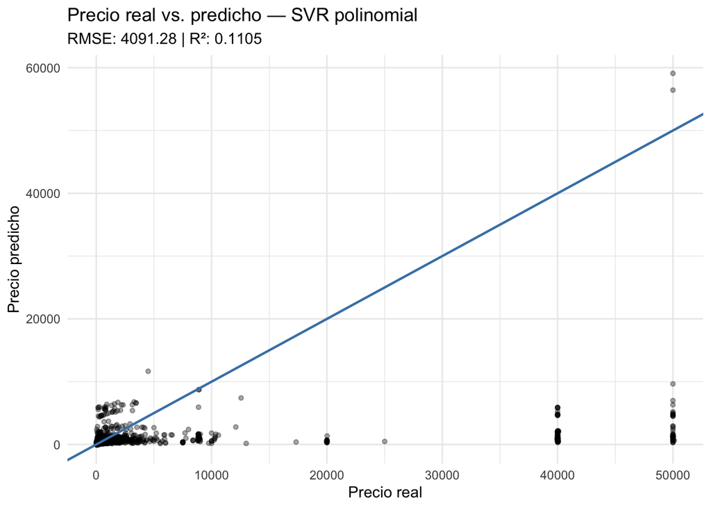

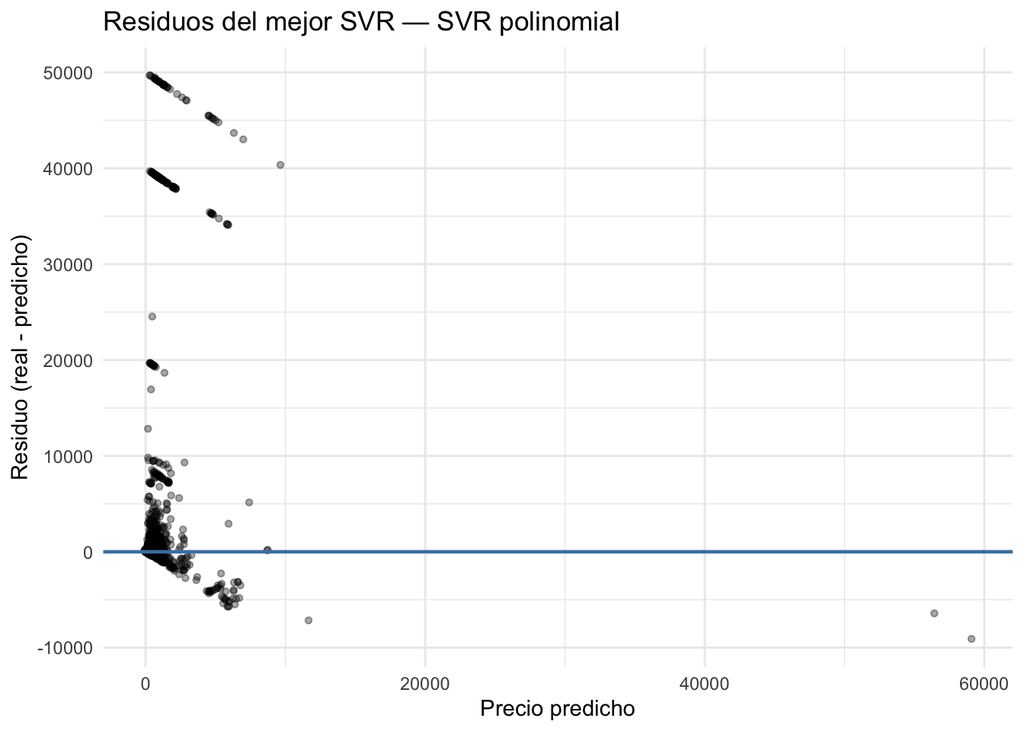

La tabla siguiente consolida el desempeno de los tres kernels SVR sobre el conjunto de prueba, ordenados de menor a mayor RMSE, para identificar cual configuracion logra el mejor equilibrio entre error y capacidad explicativa.

Comparacion de kernels SVR: desempeno sobre el conjunto de prueba

| modelo | RMSE | MAE | R2 | tiempo_segundos |
| --- | --- | --- | --- | --- |
| SVR polinomial | 4091.276 | 567.8035 | 0.1105 | NA |
| SVR lineal | 4120.543 | 567.2165 | 0.2058 | NA |
| SVR radial | 4294.919 | 637.9637 | 0.0029 | NA |

Ademas de clasificar las propiedades por categoria de precio, se desarrollaron modelos SVR para estimar directamente el precio de los alojamientos. Este enfoque complementa el analisis de clasificacion al responder una pregunta distinta: no en que rango cae el precio, sino cual es el valor esperado. Para garantizar comparaciones validas, se mantuvo el mismo particionamiento experimental utilizado en entregas anteriores.

## Comparacion con clasificadores desarrollados previamente

Los modelos SVM de clasificacion fueron entrenados bajo las mismas condiciones experimentales que los clasificadores desarrollados en entregas anteriores. Para consolidar la comparacion, se construye una tabla que incluye los resultados SVM junto con los valores de referencia de los modelos previos. Cuando los resultados de entregas anteriores esten disponibles, se deben reemplazar los campos marcados como pendientes con los valores reales obtenidos en esas sesiones.

```r
tabla_previos_clasificacion <- tibble(
  modelo              = c("Arbol de decision", "Random Forest", "Naive Bayes",
                          "KNN", "Regresion logistica"),
  accuracy_test       = c(NA_real_, NA_real_, NA_real_, NA_real_, NA_real_),
  kappa               = c(NA_real_, NA_real_, NA_real_, NA_real_, NA_real_),
  balanced_accuracy   = c(NA_real_, NA_real_, NA_real_, NA_real_, NA_real_),
  tiempo_segundos     = c(NA_real_, NA_real_, NA_real_, NA_real_, NA_real_),
  diagnostico         = rep("Pendiente de entregas anteriores", 5)
)

tabla_svm_para_comparacion <- resumen_final_svm %>%
  transmute(
    modelo            = modelo,
    accuracy_test     = accuracy_test,
    kappa             = kappa,
    balanced_accuracy = balanced_accuracy_promedio,
    tiempo_segundos   = tiempo_segundos,
    diagnostico       = diagnostico
  )

tabla_comparacion_clasificacion <- bind_rows(
  tabla_previos_clasificacion,
  tabla_svm_para_comparacion
)

kable(
  tabla_comparacion_clasificacion,
  digits  = 4,
  caption = "Comparacion de modelos de clasificacion para categoria de precio"
)
```

Comparacion de modelos de clasificacion para categoria de precio

[output not shown]

## Verificacion final de objetos

```r
objetos_finales_requeridos <- c(
  "resumen_final_svm",
  "mejor_svm",
  "tabla_comparacion_clasificacion",
  "tabla_ajuste_svm",
  "resumen_svr",
  "mejor_svr",
  "tabla_comparacion_regresion"
)

objetos_finales_faltantes <- objetos_finales_requeridos[
  !objetos_finales_requeridos %in% ls()
]

if (length(objetos_finales_faltantes) > 0) {
  stop(paste("Faltan objetos para cerrar el analisis:",
             paste(objetos_finales_faltantes, collapse = ", ")))
} else {
  cat("Todos los objetos finales requeridos estan disponibles.\n")
}
```

```
## Todos los objetos finales requeridos estan disponibles.
```

## Sintesis del desempeno de clasificacion

```r
tabla_final_clasificacion <- tabla_comparacion_clasificacion %>%
  arrange(desc(balanced_accuracy), desc(kappa), desc(accuracy_test))

kable(
  tabla_final_clasificacion,
  digits  = 4,
  caption = "Comparacion final de modelos de clasificacion para categoria de precio"
)
```

Comparacion final de modelos de clasificacion para categoria de precio

[output not shown]

```r
mejor_modelo_clasificacion_global <- tabla_final_clasificacion %>%
  filter(!is.na(accuracy_test)) %>%
  slice(1)

cat("Mejor clasificador identificado:", mejor_modelo_clasificacion_global$modelo, "\n")
```

```
## Mejor clasificador identificado: SVM lineal
```

```r
cat("Accuracy en prueba:    ", round(mejor_modelo_clasificacion_global$accuracy_test, 4), "\n")
```

```
## Accuracy en prueba:     0.8771
```

```r
cat("Kappa:                 ", round(mejor_modelo_clasificacion_global$kappa,         4), "\n")
```

```
## Kappa:                  0.7366
```

```r
cat("Balanced accuracy:     ", round(mejor_modelo_clasificacion_global$balanced_accuracy, 4), "\n")
```

```
## Balanced accuracy:      0.8623
```

Entre los modelos SVM evaluados, el seleccionado es aquel que combina mayor balanced accuracy con mejor kappa y menor brecha entre entrenamiento y prueba. El balanced accuracy pondera el desempeno en cada categoria de precio de forma equitativa, lo cual es mas informativo que el accuracy global cuando las clases tienen distinta frecuencia en el conjunto de prueba.

## Diagnostico global de ajuste

```r
tabla_ajuste_clasificacion_previos <- tibble(
  modelo         = c("Arbol de decision", "Random Forest", "Naive Bayes",
                     "KNN", "Regresion logistica"),
  accuracy_train = c(NA_real_, NA_real_, NA_real_, NA_real_, NA_real_),
  accuracy_test  = c(NA_real_, NA_real_, NA_real_, NA_real_, NA_real_)
) %>%
  mutate(
    diferencia  = accuracy_train - accuracy_test,
    diagnostico = case_when(
      is.na(diferencia) ~ "Pendiente de completar con resultados previos",
      diferencia > 0.10 ~ "Posible sobreajuste",
      accuracy_train < 0.60 & accuracy_test < 0.60 ~ "Posible desajuste",
      TRUE              ~ "Ajuste razonable"
    )
  )

tabla_ajuste_clasificacion_global <- bind_rows(
  tabla_ajuste_clasificacion_previos,
  tabla_ajuste_svm %>% select(modelo, accuracy_train, accuracy_test, diferencia, diagnostico)
)

kable(
  tabla_ajuste_clasificacion_global,
  digits  = 4,
  caption = "Diagnostico de ajuste en modelos de clasificacion"
)
```

Diagnostico de ajuste en modelos de clasificacion

[output not shown]

El diagnostico de ajuste compara la exactitud obtenida en entrenamiento contra la obtenida en prueba. Una diferencia superior al 10% sugiere que el modelo memorizo particularidades del conjunto de entrenamiento en lugar de aprender reglas generalizables, lo que reduce su utilidad para clasificar propiedades nuevas. Una exactitud baja en ambos conjuntos indica que el modelo no captura suficiente informacion de los predictores disponibles.

## Sintesis del desempeno de regresion

```r
tabla_final_regresion <- tabla_comparacion_regresion %>%
  arrange(RMSE, MAE, desc(R2))

kable(
  tabla_final_regresion,
  digits  = 4,
  caption = "Comparacion final de modelos de regresion para estimacion directa de precios"
)
```

Comparacion final de modelos de regresion para estimacion directa de precios

| modelo | RMSE | MAE | R2 | tiempo_segundos |
| --- | --- | --- | --- | --- |
| SVR polinomial | 4091.276 | 567.8035 | 0.1105 | NA |
| SVR lineal | 4120.543 | 567.2165 | 0.2058 | NA |
| SVR radial | 4294.919 | 637.9637 | 0.0029 | NA |

```r
mejor_modelo_regresion_global <- tabla_final_regresion %>%
  slice(1)

cat("Mejor modelo de regresion identificado:", mejor_modelo_regresion_global$modelo, "\n")
```

```
## Mejor modelo de regresion identificado: SVR polinomial
```

```r
cat("RMSE:", round(mejor_modelo_regresion_global$RMSE, 4), "\n")
```

```
## RMSE: 4091.276
```

```r
cat("MAE: ", round(mejor_modelo_regresion_global$MAE,  4), "\n")
```

```
## MAE:  567.8035
```

```r
cat("R2:  ", round(mejor_modelo_regresion_global$R2,   4), "\n")
```

```
## R2:   0.1105
```

## Resumen ejecutivo de decisiones

```r
resumen_decisiones <- tibble(
  tipo_problema       = c("Clasificacion de categoria de precio",
                          "Prediccion directa de precio"),
  mejor_modelo        = c(
    mejor_modelo_clasificacion_global$modelo,
    mejor_modelo_regresion_global$modelo
  ),
  criterio_principal  = c(
    "Balanced accuracy, Kappa, accuracy y estabilidad train/test",
    "RMSE, MAE, R2 y tiempo de procesamiento"
  ),
  recomendacion       = c(
    "Usar para clasificar propiedades como baratas, medias o caras",
    "Usar para estimar precios competitivos de propiedades"
  )
)

kable(resumen_decisiones, caption = "Resumen de decisiones del analisis")
```

Resumen de decisiones del analisis

| tipo_problema | mejor_modelo | criterio_principal | recomendacion |
| --- | --- | --- | --- |
| Clasificacion de categoria de precio | SVM lineal | Balanced accuracy, Kappa, accuracy y estabilidad train/test | Usar para clasificar propiedades como baratas, medias o caras |
| Prediccion directa de precio | SVR polinomial | RMSE, MAE, R2 y tiempo de procesamiento | Usar para estimar precios competitivos de propiedades |

## Recomendaciones finales para SmartStay Advisors

Los resultados obtenidos permiten analizar el problema de precios desde dos perspectivas complementarias. Por un lado, los modelos de clasificacion permiten asignar cada propiedad a una categoria de precio, lo cual facilita decisiones rapidas de segmentacion comercial. Por otro lado, los modelos de regresion permiten estimar directamente el precio esperado, lo cual resulta util cuando SmartStay Advisors necesita recomendar valores competitivos o analizar diferencias entre propiedades similares.

La comparacion de modelos se realizo manteniendo los mismos conjuntos de entrenamiento y prueba utilizados en entregas anteriores. Esto permitio que las diferencias observadas fueran atribuibles al comportamiento de los algoritmos y no a cambios en la particion de los datos. Para clasificacion, la seleccion del mejor modelo considero accuracy, Kappa, balanced accuracy, errores por clase y estabilidad entre entrenamiento y prueba. Para regresion, la comparacion se baso principalmente en RMSE, MAE y R2.

El diagnostico de ajuste muestra si los modelos estan aprendiendo patrones generalizables o si dependen demasiado del conjunto de entrenamiento. Una diferencia amplia entre entrenamiento y prueba sugiere sobreajuste, mientras que resultados bajos en ambos conjuntos pueden indicar desajuste. Este analisis es fundamental para evitar recomendar un modelo que funcione bien en datos historicos pero falle al evaluar nuevas propiedades.

Con base en las metricas consolidadas, el modelo recomendado debe ser aquel que logre el mejor equilibrio entre desempeno predictivo, estabilidad y costo computacional. Esta decision permite que SmartStay Advisors utilice modelos de mineria de datos no solo para estimar precios, sino tambien para entender mejor los factores que influyen en la ocupacion, rentabilidad y posicionamiento de las propiedades.